# TidyVerse Recipe

Zainab.O

2023-10-29

OKAY , so I am being asked to CREATE a project using tidyverse I personally want to say, its sad that we have no fall break.students need a break.It’s school week after week. I want a Jewish Holiday off. and by off I mean the assignment is not due that following Sunday. I did not even get class off because my lectures are mid week but I digress. It is probably a managemnt thing. Need some soft skills

Let’s get into the assignment

The purpose of this assignment is the following: Your task here is to Create an Example. Using one or more TidyVerse packages, and any dataset from fivethirtyeight.com or Kaggle, create a programming sample “vignette” that demonstrates how to use one or more of the capabilities of the selected TidyVerse package with your selected dataset.

We decided on tattoo data because I like them but my mother and Co believe them to be things for the heathens so the article touch me and my stressed out heart.

DOWNLOAD PACKAGES

```r
library(tidyverse)
library(dplyr)
library(readr)
```

```r
datadf = read_csv("https://raw.githubusercontent.com/fivethirtyeight/data/master/nba-tattoos/nba-tattoos-data.csv")
head(datadf)
```

```
## # A tibble: 6 × 2
##   `Player Name` `Tattoos yes/no`
##   <chr>         <chr>
## 1 A.J. Price    no
## 2 Aaron Gray    no
## 3 Al Horford    no
## 4 Al Jefferson  no
## 5 Al Thornton   no
## 6 Alan Anderson no
```

```r
summary(datadf)
```

```
##  Player Name        Tattoos yes/no
##  Length:636         Length:636
##  Class :character   Class :character
##  Mode  :character   Mode  :character
```

```r
newdf = datadf %>%
  group_by(`Tattoos yes/no`) %>%
  count()

newdf
```

```
## # A tibble: 2 × 2
## # Groups:   Tattoos yes/no [2]
##   `Tattoos yes/no`     n
##   <chr>            <int>
## 1 no                 288
## 2 yes                348
```

#Here I have a bar graph demonstrating the frequency of no tattoos vs tattoos of the basketball players in my data

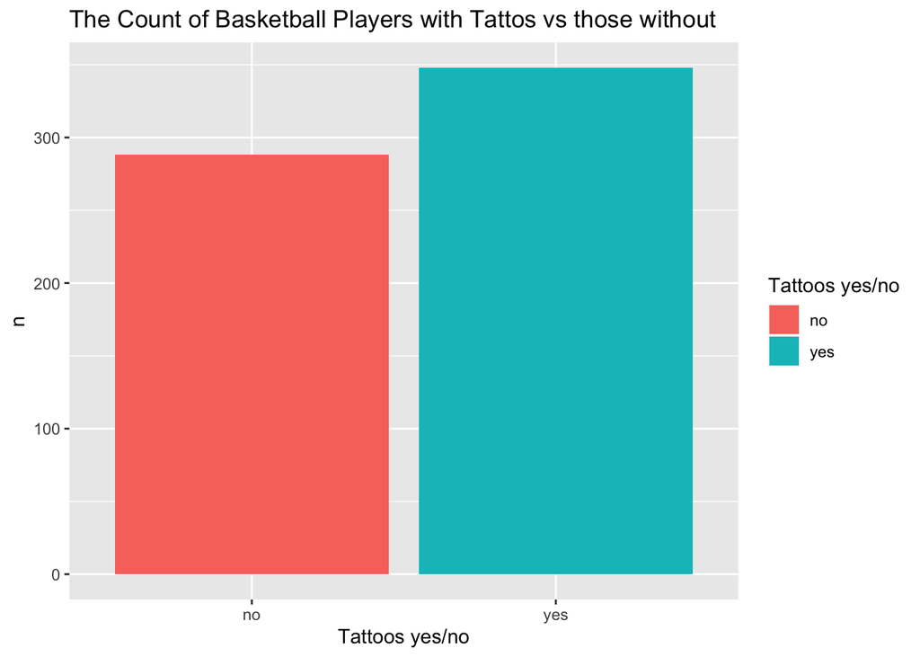

```r
newdf %>%
  ggplot(aes(x=`Tattoos yes/no`,y=n, fill=`Tattoos yes/no`))+
  geom_bar(stat = "identity")+
  ggtitle("The Count of Basketball Players with Tattos vs those without")
```

Reference data : https://raw.githubusercontent.com/fivethirtyeight/data/master/nba-tattoos/nba-tattoos-data.csv Article: https://fivethirtyeight.com/features/what-ethan-swan-learned-from-tracking-every-tattoo-in-the-nba/